# Heatmaps with R

# Objectives

In this section we will learn how to create **heatmaps**, a popular graphical method for visualizing high-dimensional data. Heatmaps:

- visualize data that are in a form of a table or a matrix, whose entries are numbers corresponding to some variables.
- encode the information in the tables as a grid of colored cells.
- are used in many fields to visualize observations, correlations, sparsity or missing data patterns.

The rows and the columns of the heatmas are usually ordered to highlight the patterns in the data, and are usually accompanied by dendograms[^1].

The material presented here is largely based on the following resources:

- [Making heatmaps with R for microbiome analysis](http://www.molecularecologist.com/2013/08/making-heatmaps-with-r-for-microbiome-analysis/) tutorial
- [`heatmaply` vignette](https://cran.r-project.org/web/packages/heatmaply/vignettes/heatmaply.html)
- [`plotly` example](https://plot.ly/r/heatmaps/)

All presented material is under a [Creative Commons Attribution-NonCommercial-ShareAlike 4.0 International License] (https://creativecommons.org/licenses/by-sa/4.0/).

# Install and load packages

```r
# Clear the workspace
rm(list = ls())
# List of package needed for this workshop
reqpkg <- c("gplots", "plotly", "heatmaply", "RColorBrewer")
# Check if the packages are installed:
inpkg = installed.packages()[, "Package"] #installed packages
neededpkg = reqpkg[!reqpkg %in% inpkg]
if(length(neededpkg) > 0){
  stop(paste("\n Need to install the following package:", neededpkg))
}
# Load all required packages and show version
for(i in reqpkg){
    print(paste(i, "version:", packageVersion(i)))
    library(i, quietly=TRUE, verbose=FALSE, warn.conflicts=FALSE, character.only=TRUE)
}
```

```
[1] "gplots version: 3.0.1"
[1] "plotly version: 3.6.0"
[1] "heatmaply version: 0.3.2"
[1] "RColorBrewer version: 1.1.2"
```

# Chose a dataset

**Motor Trend Car Road Tests**

> The data was extracted from the 1974 Motor Trend US magazine, and comprises fuel consumption and 10 aspects of automobile design and performance for 32 automobiles (1973–74 models).

```r
?mtcars
head(mtcars)
```

```
                   mpg cyl disp  hp drat    wt  qsec vs am gear carb
Mazda RX4         21.0   6  160 110 3.90 2.620 16.46  0  1    4    4
Mazda RX4 Wag     21.0   6  160 110 3.90 2.875 17.02  0  1    4    4
Datsun 710        22.8   4  108  93 3.85 2.320 18.61  1  1    4    1
Hornet 4 Drive    21.4   6  258 110 3.08 3.215 19.44  1  0    3    1
Hornet Sportabout 18.7   8  360 175 3.15 3.440 17.02  0  0    3    2
Valiant           18.1   6  225 105 2.76 3.460 20.22  1  0    3    1
```

# Generate a basic heatmap

Using basic `stats::heatmap` function:

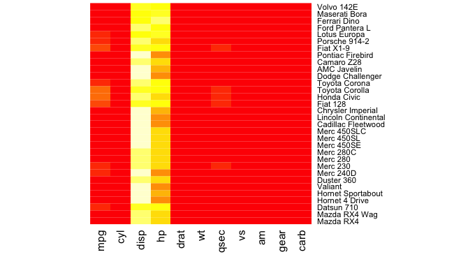

```r
heatmap(as.matrix(mtcars), Rowv = NA, Colv = NA)
```

Using `plotly` package you can get an interactive heatmap:

```r
library(plotly)
plot_ly(z = as.matrix(mtcars), type = "heatmap", colorscale = "Hot")
```

[interactive chart not shown]

# More complicated heatmaps

With ordered rows and columns and the dendograms showing the rows and columns clusters.

Using `heatmap()`

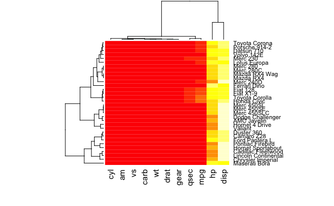

```r
heatmap(as.matrix(mtcars))
```

Using `gplots::heatmap.2()`:

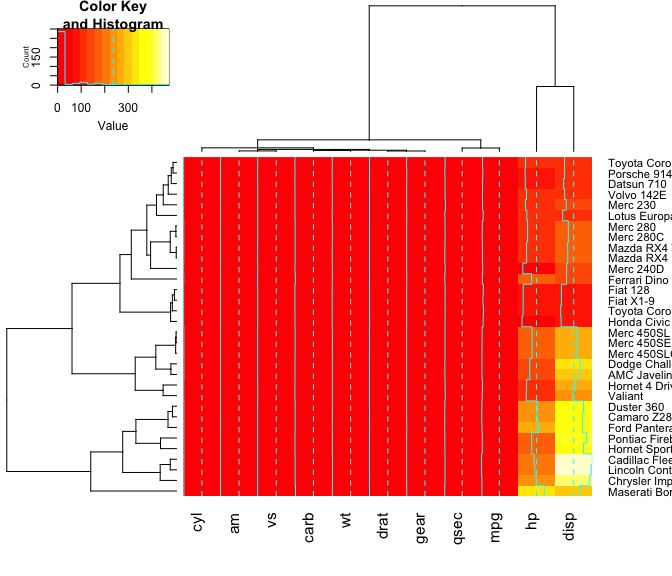

```r
heatmap.2(as.matrix(mtcars))
```

You can also add the side colors and your own dendogram:

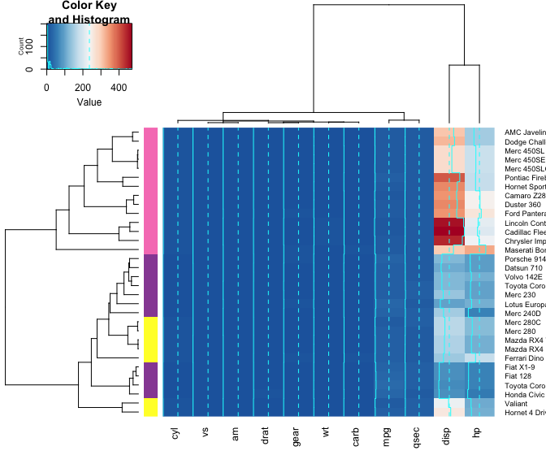

```r
# Define color scheme
scaleredblues <- colorRampPalette(colors = rev(brewer.pal(9, "RdBu")))(100)
# Cluster rows
data.dist.r <- dist(mtcars, method = "manhattan")
row.clus <- hclust(data.dist.r, "aver")
# Cluster columns
data.dist.c <- dist(t(mtcars), method = "manhattan")
col.clus <- hclust(data.dist.c, "aver")
# Create a variable for side bar
varCyl <- brewer.pal(9, "Set1")[mtcars$cyl]
heatmap.2(as.matrix(mtcars),
          Rowv = as.dendrogram(row.clus),
          Colv = as.dendrogram(col.clus),
          col = scaleredblues,
          RowSideColors = varCyl) # this puts in the annotation for the samples margins = c(10, 3))
```

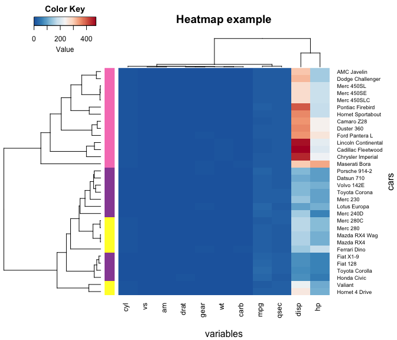

```r
heatmap.2(as.matrix(mtcars),
          Rowv = as.dendrogram(row.clus),
          Colv = as.dendrogram(col.clus),
          col = scaleredblues,
          RowSideColors = varCyl,
          margins = c(6, 9),
          trace = "none", density.info = "none",
          xlab = "variables", ylab = "cars",
          main = "Heatmap example", lhei = c(2, 8))
```

# `heatmaply` for complex interactive heatmaps

```r
library(heatmaply)
heatmaply(mtcars)
```

[interactive chart not shown]

```r
heatmaply(mtcars) %>% layout(margin = list(l = 150, b = 50))
```

[interactive chart not shown]

Heatmaps with the variable correlations:

```r
heatmaply(cor(mtcars), limits = c(-1,1)) %>%
  layout(margin = list(l = 40, b = 40))
```

[interactive chart not shown]

Color the dendogram branches:

```r
heatmaply(as.matrix(mtcars), k_col = 2, k_row = 3) %>%
  layout(margin = list(l = 150, b = 160), autosize = F, width = 500, height = 600)
```

[interactive chart not shown]

```r
heatmaply(as.matrix(mtcars), colors = scaleredblues, k_col = 2, k_row = 3) %>%
  layout(margin = list(l = 150, b = 160), autosize = F, width = 500, height = 600)
```

[interactive chart not shown]

# Exercise

Microbiome dataset from DIABIMMUNE study on the dynamics of the infant gut mictobiome and the development of type I diabetes (T1D).

Download a table of read counts:

```r
dataUrl <- "https://pubs.broadinstitute.org/diabimmune/uploads/attachments/82/diabimmune_t1d_16s_otu_table.txt"
download.file(dataUrl, "./data/readCounts.txt")
```

```r
dataTable <- read.table("./data/readCounts.txt")
dim(dataTable)
```

```
[1] 2240  785
```

```r
taxTable <- dataTable[, 779:ncol(dataTable)]
dataTable <- dataTable[, 1:778]
```

Subset the table:

```r
dat <- dataTable[sample(1:nrow(dataTable), 150), sample(1:ncol(dataTable), 30)]
head(dat)
```

```
     V204 V6 V519 V370 V255 V228 V113 V437 V566 V510 V544 V498 V710 V31 V577 V612 V562 V751 V738 V662 V348 V493 V476 V580 V191 V372 V71 V405 V91 V251
738     0  0    0    0    6    0    0    0    0    0    0    0   13   0    0    0    0    0    0    0    0    0    0   28    0    0   0    0   0    0
638     0  0    0    0    0    0    0    0    1    0    0    0    0   0    0    0    0    1    0    0    0    0    0    0    0    0   0    0   0    0
2031    0  0    0    0    0    0    0    0   12    0    0    0    0   0    0    1    0    0    0    0    0    4    0    0    0    0   0    0   0    0
337     2  9    0    0    5    1    0    0    0    0    0    0    8   0    5    0    3   13    0    6    3    0    0    0    0    0   6   20   0    5
1778    0  0    0    0    0    0    0    0    0    0    0    0    0   0    0    1    0    0    0    0    0    0    0    0    0    0   1    0   0    0
254     0  2    4    0   41    1    0    0    0    0    0    0    0   0   27   17   10    2    0    0    0    0    0    0    0    0   0   61   0    3
```

Generate the heatmap using `gplots::heatmap.2` with a chosen color scheme and set `trace = "none", density.info = "none"`

```r
# (? ...)
```

You can install a useful color scheme package `viridis`:

```r
#install.packages("viridis")
library(viridis)
```

Generate an interactive heatmap using `heatmaply`:

```r
# (? ...)
```

[^1]: https://www.r-statistics.com/2016/05/heatmaply-interactive-heat-maps/#more-61399